# PS630 Lab: Interaction Effect

Haohan Chen

November 16, 2018

## Load the Package

```r
library(readstata13)
d = readstata13::read.dta13("TeachingRatings.dta")

library(tidyverse)
```

## Fit a Model

```r
m = lm(course_eval ~ beauty + female + age + minority + age:minority + onecredit + nnenglish, data = d)
summary(m)
```

```
##
## Call:
## lm(formula = course_eval ~ beauty + female + age + minority +
##     age:minority + onecredit + nnenglish, data = d)
##
## Residuals:
##      Min       1Q   Median       3Q      Max
## -1.82026 -0.32847  0.04322  0.37274  1.07701
##
## Coefficients:
##               Estimate Std. Error t value Pr(>|t|)
## (Intercept)   4.251755   0.140011  30.367  < 2e-16 ***
## beauty        0.157155   0.031641   4.967 9.65e-07 ***
## female       -0.175775   0.050469  -3.483 0.000544 ***
## age          -0.003653   0.002692  -1.357 0.175327
## minority     -1.688936   0.520654  -3.244 0.001266 **
## onecredit     0.585604   0.107053   5.470 7.43e-08 ***
## nnenglish    -0.219481   0.104826  -2.094 0.036833 *
## age:minority  0.033113   0.011218   2.952 0.003323 **
## ---
## Signif. codes:  0 '***' 0.001 '**' 0.01 '*' 0.05 '.' 0.1 ' ' 1
##
## Residual standard error: 0.5089 on 455 degrees of freedom
## Multiple R-squared:  0.1715, Adjusted R-squared:  0.1587
## F-statistic: 13.45 on 7 and 455 DF,  p-value: 7.988e-16
```

## What is the model?

$$course\_eval_i = \beta_0 + \beta_1 beauty_i + \beta_2 female_i + \beta_3 age_i + \beta_4 minority_i + \beta_5 age_i \times minority_i + \beta_6 onecredit_i + \beta_7 nnenglish_i + \varepsilon_i$$

With the above model fit

$$\hat{course\_eval_i} = \hat{\beta}_0 + \hat{\beta}_1 beauty_i + \hat{\beta}_2 female_i + \hat{\beta}_3 age_i + \hat{\beta}_4 minority_i + \hat{\beta}_5 age_i \times minority_i + \hat{\beta}_6 onecredit_i + \hat{\beta}_7 nnenglish_i$$

## Interpretation

### Question 1a: What is the marginal effect of `beauty` on `course_eval`?

$$\frac{\partial \hat{course\_eval}}{\partial beauty} = \hat{\beta}_1$$

Note: `beauty` is a continuous variable

Answer: One unit increase in `beauty` is associated with $\hat{\beta}_1$ change in `course_eval`.

### Question 1b

Hypothetically, if `beauty` is a dummy variable (say, `beauty=1` means good-looking and `beauty=0` means otherwise), what is the marginal effect?

Answer: When `beauty` change from 0 to 1, `course_eval` change by $\hat{\beta}_1$.

### Question 2: What is the marginal effect of `age` on `course_eval`

$$\frac{\partial \hat{course\_eval}}{\partial age} = \hat{\beta}_3 + \hat{\beta}_5 \times minority$$

Note: This is a *continuous* variable.

Answer: One unit increase in `age` is associated with $\hat{\beta}_3 + \hat{\beta}_5 \times minority$ units increase of `course_eval`

### Question 3: What is the marginal effect of `minority` on `course_eval`

$$\frac{\partial \hat{course\_eval}}{\partial minority} = \hat{\beta}_4 + \hat{\beta}_5 \times age$$

Note: This is a *dummy* variable which only takes values 0 and 1.

Answer: When `minority` change from 0 to 1, `course_eval` change by $\hat{\beta}_4 + \hat{\beta}_5 \times age$.

## Obtaining the Coefficitns: Estimates and Uncertainty

We can obtain $\beta$’s and their confidence intervals with the functions provided by the `lm` package. We can also do it in a Monte Carlo way. That is, we simulate a set of coefficients to account for its uncertainty.

**You need not understand the details of the Monte Carlo approach**. It is actually much more straightfoward that it sounds. Useful materials:

- Multivariate Normal Distribution: https://en.wikipedia.org/wiki/Multivariate_normal_distribution. This Explain what we do with the `mvrnorm` function.
- Central Limit Theorem: This explain why we want to use multivariate normal distribution to simulate the coefficients. https://en.wikipedia.org/wiki/Central_limit_theorem
- A not-so-technical overview of this method with examples in R: https://aosmith.rbind.io/2018/01/09/simulate-simulate-part1/

```r
# Getting the coefficients and confidence interval from the model directly
# Easier way. Black box, not flexible
coef(m)
```

```
##  (Intercept)       beauty       female          age     minority
##  4.251755325  0.157155067 -0.175774578 -0.003653495 -1.688936396
##    onecredit    nnenglish age:minority
##  0.585603624 -0.219481037  0.033112518
```

```r
confint(m)
```

```
##                     2.5 %       97.5 %
## (Intercept)   3.976607887  4.526902763
## beauty        0.094974028  0.219336107
## female       -0.274955689 -0.076593467
## age          -0.008942881  0.001635892
## minority     -2.712121651 -0.665751141
## onecredit     0.375223219  0.795984030
## nnenglish    -0.425483877 -0.013478197
## age:minority  0.011067472  0.055157564
```

```r
# The Monte Carlo approach
###########################
beta_m = coef(m) # mean (estimated) coefficients
beta_vcov = vcov(m) # Variance-covariance matrix of the coefficients
# Simulate beta's
set.seed(1111) # Set a seed so that you replicate the result
beta_sim = MASS::mvrnorm(n = 1000, mu = beta_m, Sigma = beta_vcov)
```

Let’s take a look at what we get

```r
head(beta_sim)
```

```
##      (Intercept)    beauty     female          age   minority onecredit
## [1,]    4.153517 0.1381243 -0.2060637 -0.001547248 -1.6510008 0.5807137
## [2,]    4.498248 0.1507916 -0.1632831 -0.008597166 -2.3606333 0.4105829
## [3,]    4.289037 0.2011869 -0.1702125 -0.005152172 -2.0212608 0.5345788
## [4,]    4.311073 0.1514905 -0.1370938 -0.004975464 -2.2901561 0.4769963
## [5,]    4.110964 0.1721929 -0.1256407 -0.001241784 -1.7524811 0.4131815
## [6,]    4.170906 0.1838771 -0.1914333 -0.001748307 -0.1650144 0.6816267
##        nnenglish age:minority
## [1,] -0.27911174  0.033241047
## [2,] -0.18170498  0.046690420
## [3,] -0.26501868  0.042848455
## [4,]  0.02694798  0.046131451
## [5,] -0.19972180  0.036282349
## [6,] -0.28886897  0.001973286
```

We can first try to obtain what we can get from the `lm` function (`confint`)

```r
# Compare with what you get from confint
###########################################
beta_sim %>%
  apply(2, function(x) quantile(x, c(0.025, 0.975))) %>%
  t()
```

```
##                      2.5%        97.5%
## (Intercept)   3.988154086  4.532211118
## beauty        0.092941619  0.225708137
## female       -0.274231568 -0.081332744
## age          -0.008867204  0.001546027
## minority     -2.627778367 -0.664558774
## onecredit     0.381320537  0.791737681
## nnenglish    -0.433488241 -0.014705876
## age:minority  0.011706168  0.054258479
```

```r
confint(m)
```

```
##                     2.5 %       97.5 %
## (Intercept)   3.976607887  4.526902763
## beauty        0.094974028  0.219336107
## female       -0.274955689 -0.076593467
## age          -0.008942881  0.001635892
## minority     -2.712121651 -0.665751141
## onecredit     0.375223219  0.795984030
## nnenglish    -0.425483877 -0.013478197
## age:minority  0.011067472  0.055157564
```

```r
# Get the 3 critical quantiles all together (2.5%, 50%, 97.5%)
###############################################################

coef_CI = beta_sim %>%
  apply(2, function(x) quantile(x, c(0.025, 0.05, 0.5, 0.95, 0.975))) %>%
  t()
coef_CI
```

```
##                      2.5%           5%          50%           95%
## (Intercept)   3.988154086  4.025319451  4.248434987  4.4817786661
## beauty        0.092941619  0.104571051  0.158096176  0.2124990595
## female       -0.274231568 -0.256631248 -0.173167725 -0.0921623161
## age          -0.008867204 -0.008052788 -0.003639186  0.0007595384
## minority     -2.627778367 -2.484044070 -1.674513266 -0.8321449674
## onecredit     0.381320537  0.413114425  0.585443576  0.7682875677
## nnenglish    -0.433488241 -0.395687959 -0.222294554 -0.0401701954
## age:minority  0.011706168  0.013611587  0.032853544  0.0503346140
##                     97.5%
## (Intercept)   4.532211118
## beauty        0.225708137
## female       -0.081332744
## age           0.001546027
## minority     -0.664558774
## onecredit     0.791737681
## nnenglish    -0.014705876
## age:minority  0.054258479
```

## Plot the coefficients

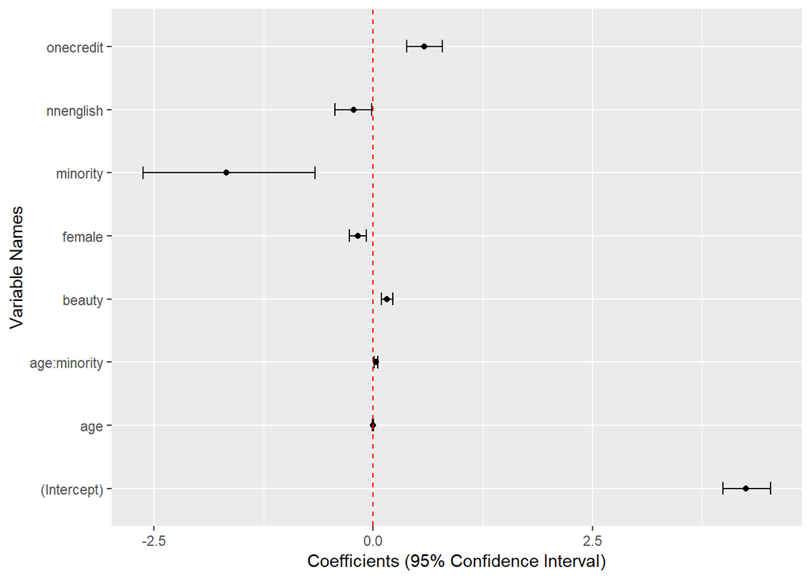

```r
# How to plot it with ggplot?
coef_CI %>%
  as.data.frame() %>%
  rownames_to_column() %>%
  ggplot(aes(x = rowname, y = `50%`)) +
  geom_point() +
  geom_errorbar(aes(ymin = `2.5%`, ymax = `97.5%`), width = 0.2) +
  # geom_linerange(aes(ymin = `5%`, ymax = `95%`), size = 1) + # if you want to plot 90% CI additionally
  geom_hline(yintercept = 0, color = "red", linetype = 2) +
  xlab("Variable Names") + ylab("Coefficients (95% Confidence Interval)") +
  coord_flip()
```

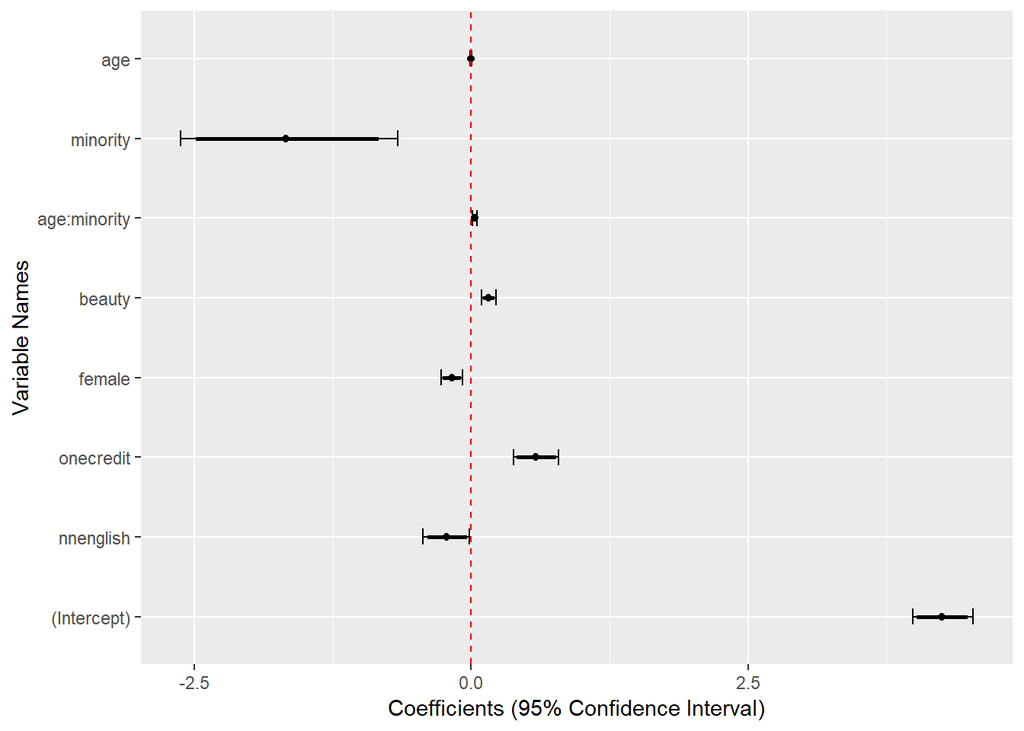

```r
# Aside: want to adjust the order of coefficients?
# Make row names a factor whose levels you manually order
# Copy the above code

coef_CI %>%
  as.data.frame() %>%
  rownames_to_column() %>%
  mutate(rowname = factor(rowname, levels = rev(c("age", "minority", "age:minority", "beauty", "female", "onecredit", "nnenglish", "(Intercept)")))) %>%
  # Note on rev -- to take care of the consequence of coord_flip
  ggplot(aes(x = rowname, y = `50%`)) +
  geom_point() +
  geom_errorbar(aes(ymin = `2.5%`, ymax = `97.5%`), width = 0.2) +
  geom_linerange(aes(ymin = `5%`, ymax = `95%`), size = 1) +
  geom_hline(yintercept = 0, color = "red", linetype = 2) +
  xlab("Variable Names") + ylab("Coefficients (95% Confidence Interval)") +
  coord_flip()
```

```r
# Play with the above code by commenting out some lines to see what change.
```

## Plotting the Marginal Effect of a Variable

Back to the business: How do we plot the interaction effect?? Let’s set it straight, what are the variables of the x-axis and the y-axis?

### Marginal effect of a continuous variable that has no interaction effect

Example: We would like to plot the marginal effect of `beauty` on `course_eval`

- x-Axis: Value of ?? (anything, the marginal effect is constant conditional on any other independent variables)
- y-Axis: Value of $\frac{\partial \hat{course\_eval}}{\partial beauty} = \beta_1$

No interaction effect. This means the marginal effect of ``beauty` is constant. There isn’t much value to visualize it (though you can!)

### Marginal effect of a dummy variable that interacts with a continuous variable

Example: We would like to plot the marginal effect of `minority` on `course_eval`

```r
# Step 0: Does the marignal effect depend on any other variables?
# Yes. Age

# Step 1: Get summary statistics of the variables identified in the above step
summary(d$age)
```

```
##    Min. 1st Qu.  Median    Mean 3rd Qu.    Max.
##   29.00   42.00   48.00   48.37   57.00   73.00
```

```r
# Step 2: Simulate a sequence of the variable of interest in its range
age_sim = seq(min(d$age), max(d$age), length.out=20)

# Step 3: Multiply the sequence with the simulated beta's
quantiles = c(0.025, 0.5, 0.975)

me_minority = apply(beta_sim[, c("age", "age:minority")], 1, function(x) x["age"] * 1 + x["age:minority"] * age_sim) %>%
  apply(1, function(x) quantile(x, quantiles)) %>%
  as.data.frame() %>%
  t() %>%
  as.data.frame() %>%
  mutate(variable = age_sim)

me_minority
```

```
##         2.5%       50%    97.5% variable
## 1  0.3373011 0.9506596 1.569272 29.00000
## 2  0.3641930 1.0269067 1.694707 31.31579
## 3  0.3910850 1.1031538 1.820142 33.63158
## 4  0.4179769 1.1794009 1.945680 35.94737
## 5  0.4448689 1.2555189 2.071393 38.26316
## 6  0.4717608 1.3315972 2.197107 40.57895
## 7  0.4986625 1.4076755 2.322820 42.89474
## 8  0.5255657 1.4837538 2.448533 45.21053
## 9  0.5524689 1.5598320 2.574247 47.52632
## 10 0.5793720 1.6359103 2.699899 49.84211
## 11 0.6062752 1.7119809 2.825463 52.15789
## 12 0.6331784 1.7880145 2.951027 54.47368
## 13 0.6600816 1.8640480 3.076591 56.78947
## 14 0.6869847 1.9400816 3.202155 59.10526
## 15 0.7138879 2.0161151 3.327718 61.42105
## 16 0.7407911 2.0921487 3.453282 63.73684
## 17 0.7676942 2.1681822 3.578846 66.05263
## 18 0.7945974 2.2442215 3.704410 68.36842
## 19 0.8215006 2.3203087 3.829974 70.68421
## 20 0.8484037 2.3963959 3.955538 73.00000
```

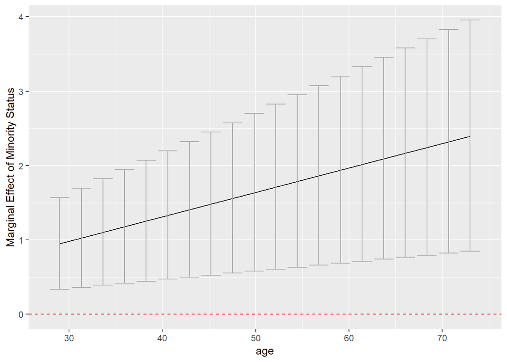

```r
me_minority %>%
  ggplot(aes(x = variable, y = `50%`)) +
  geom_line() + geom_errorbar(aes(ymin = `2.5%`, ymax = `97.5%`), color = "darkgray") +
  geom_hline(yintercept = 0, color = "red", linetype = 2) +
  xlab("age") + ylab("Marginal Effect of Minority Status")
```

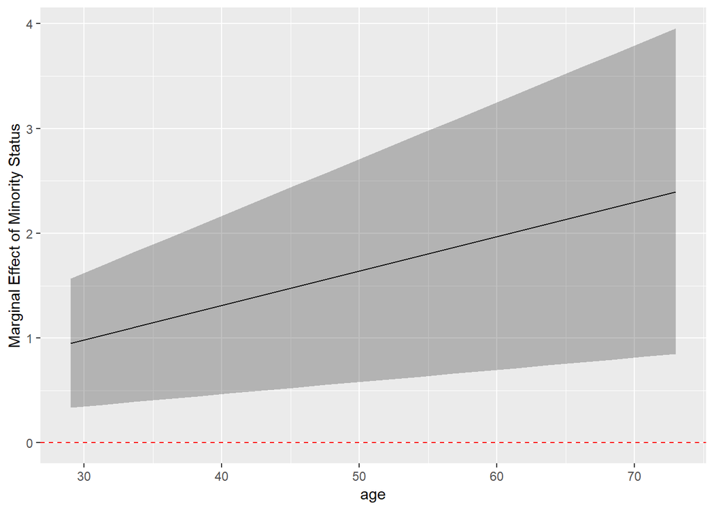

```r
me_minority %>%
  ggplot(aes(x = variable, y = `50%`)) +
  geom_line() + geom_ribbon(aes(ymin = `2.5%`, ymax = `97.5%`), alpha = 0.3) +
  geom_hline(yintercept = 0, color = "red", linetype = 2) +
  xlab("age") + ylab("Marginal Effect of Minority Status")
```

### Marginal effect of a continuous variable that interacts with a dummy variable

```r
# Step 0: Does the marignal effect depend on any other variables?
# Yes. minority

# Step 1: Get summary statistics of the variables identified in the above step
table(d$minority)
```

```
##
##   0   1
## 399  64
```

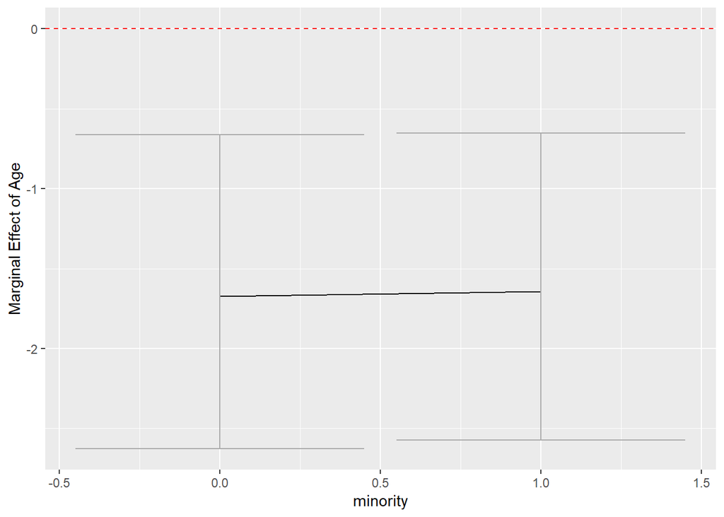

```r
# Step 2: Simulate a sequence of the variable of interest in its range
minority_sim = c(0, 1)

# Step 3: Multiply the sequence with the simulated beta's
quantiles = c(0.025, 0.5, 0.975)

me_age = apply(beta_sim[, c("minority", "age:minority")], 1, function(x) x["minority"] * 1 + x["age:minority"] * minority_sim) %>%
  apply(1, function(x) quantile(x, quantiles)) %>%
  as.data.frame() %>%
  t() %>%
  as.data.frame() %>%
  mutate(variable = minority_sim)

# Plot: using the original code: Bad
# Problem: An informative plot for a variable interacting with a dummy is slightly different.
me_age %>%
  ggplot(aes(x = variable, y = `50%`)) +
  geom_line() + geom_errorbar(aes(ymin = `2.5%`, ymax = `97.5%`), color = "darkgray") +
  geom_hline(yintercept = 0, color = "red", linetype = 2) +
  xlab("minority") + ylab("Marginal Effect of Age")
```

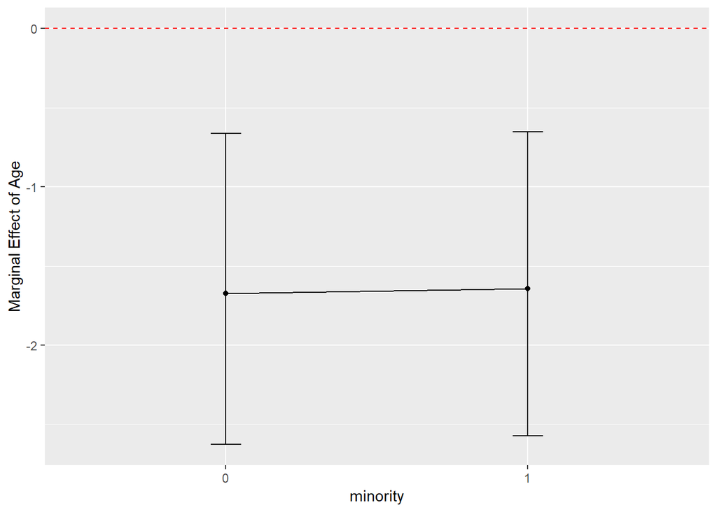

```r
me_age %>%
  mutate(variable = factor(variable)) %>%
  ggplot(aes(x = variable, y = `50%`)) +
  geom_point() +
  geom_line(aes(group = 1)) + geom_errorbar(aes(ymin = `2.5%`, ymax = `97.5%`), width = 0.1) +
  geom_hline(yintercept = 0, color = "red", linetype = 2) +
  xlab("minority") + ylab("Marginal Effect of Age")
```

```r
# This also apply for interaction with categorical variables (more than two classes)
```